# Notebook 3

A torus is a geometric surface which has dimensions defined by two radii: the major radius (R) and the minor radius (r). The major radius is the distance from the center of the torus' hole to the center of the circular tube. The minor radius is the radius of the circular tube. In simpler terms, a torus contains one large circle and many smaller circles as the vertical cross sections.

Simulating Brownian motion on the Torus $T^2$ is very similar to on the Sphere $S^2$. We can use Euler-Maruyama and tangent-space Gaussian noise to project each space back onto the torus for a certain number of walkers and time steps.

```python
# Imports
import numpy as np
import math
import plotly.graph_objects as go
import matplotlib.pyplot as plt

import sys
sys.path.append("..")
from src.manifolds.torus import Torus
```

The `project_to_manifold` method in torus.py maps points back onto the torus. We must verify that it is working correctly before continuing to simulations and plots.

It is important to check whether points on, outside, and inside the torus get projected onto the torus surface. The method is simply called for a point that is already on the torus. To check points inside and outside the torus, we move a point already on the torus either inside or outside the torus. The normal vector points perpendicular to the torus surface at that point, so when it is computed, multipled by a constant, and then added/subtracted to the point already on the torus, it moves the point inward or outward the torus surface. Then, we can verify whether the updated point returns back to the torus when the `project_to_manifold` method is applied.

Finally, all points must satisfy the torus equation, expressed as

$$ (\sqrt{x^2 + y^2} - R)^2 + z^2 = r^2 $$

where $x, y, z$ are the Cartesian coordinates, $R$ is the major radius, and $r$ is the minor radius.

```python
# Unit tests for project_to_manifold method

# Point already on the torus
# Create new torus object
R = 3
r = 1
torus = Torus(R, r)
# Set values for u, v angles on the torus
u = 0
v = 0
# Parametrize point on torus and project back to torus
point = torus.parametrize(u, v)
updated_point = torus.project_to_manifold(point)
# Verify that both points are equivalent within small tolerance
assert np.allclose(point, updated_point, atol=1e-5)

# Point is outside of the tube
torus_point = torus.parametrize(u, v)
torus_point_normal = torus.normal_vector(u, v)

point_outside = torus_point + 0.1 * torus_point_normal
new_torus_point = torus.project_to_manifold(point_outside)

assert np.allclose(torus_point, new_torus_point, atol=1e-5)

# Point is inside the tube
point_inside = torus_point - 0.1 * torus_point_normal
new_torus_point = torus.project_to_manifold(point_inside)

assert np.allclose(torus_point, new_torus_point, atol=1e-5)

# Returned point satisfies torus equation (outside)
projected_point = torus.project_to_manifold(point_outside)

x = projected_point[0]
y = projected_point[1]
z = projected_point[2]

lhs = (math.sqrt(x**2 + y**2) - R)**2 + z**2
r_squared = r**2

assert np.allclose(lhs, r_squared, atol=1e-5)

# Returned point satisfies torus equation (inside)
projected_point = torus.project_to_manifold(point_inside)

x = projected_point[0]
y = projected_point[1]
z = projected_point[2]

lhs = (math.sqrt(x**2 + y**2) - R)**2 + z**2
r_squared = r**2

assert np.allclose(lhs, r_squared, atol=1e-5)
```

After verifying that the `project_to_manifold` method works as expected, we can begin to set up the Brownian motion simulation.

A torus is initialized with major radius $R$ of 3 and minor radius $r$ of 1. The Brownian motion simulation uses a time step of $dt = 0.01$ and runs for $T = 100000$ steps. The trajectory starts at the $(u, v)$ coordinates (0, 0). $u$ is the major angle, which represents the rotation around the main central hole of the torus. $v$ is the minor angle, which represents the rotation inside of the tube. Both angles have a range of 0 to $2\pi$.

The parametric equations to calculate the Cartesian coordinates from u, v are

$$ x = (R + r\cos(v))\cos(u) $$

$$ y = (R + r\cos(v))\sin(u) $$

$$ z = r\sin(v) $$

By using the `parametrize` method in torus.py, the $(u, v)$ coordinates are converted into $(x, y, z)$ coordinates. From the chosen values, the Cartesian coordinates are (4, 0, 0).

```python
# Run long simulation

# Create a torus object
R = 3
r = 1
torus = Torus(R, r)

# Chosen parameters
dt = 0.01 # Time step of the simulation
T = 100000 # Number of steps
u = 0 # Toroidal angle
v = 0 # Poloidal angle

# Choose a starting point on the torus
point = torus.parametrize(u, v)
```

The simulation is run for $T = 100000$ time steps using the `euler_maruyama_step` method. The trajectory is stored in an array, which contains the Cartesian coordinates of every sampled point.

To later analyze the distribution of Brownian motion on the torus, the coordinates are converted into torus coordinates $(u, v)$. This is done using the formulas

$$ u = \operatorname{atan2}(y, x) $$

$$ v = \operatorname{atan2}\!\left(z, \sqrt{x^2+y^2} - R\right) $$

We use the modulo operator to map both angles into the interval

$$ [0, 2\pi) $$

This is done to have a consistent coordinate system for the empirical distributions and comparison to the theoretical densities.

```python
# Store trajectory of path after T number of steps in the simulation
path = [point.copy()] # Initialize array to contain the starting point
for i in range(T):
    point = torus.euler_maruyama_step(point, dt)
    path.append(point.copy())

# Get x, y, z-coordinates for plotting
path = np.array(path) # Convert to numpy array to enable column indexing
x_coor = path[:, 0]
y_coor = path[:, 1]
z_coor = path[:, 2]

# Convert every sampled point to u and v values
rho = np.sqrt(x_coor**2 + y_coor**2)
u_values = (np.arctan2(y_coor, x_coor)) % (2*np.pi)
v_values = (np.arctan2(z_coor, rho - R)) % (2*np.pi)
```

We can now plot the trajectory on the torus surface using a meshgrid. The formulas used to create each axis of the surface are the torus parameterizations for $x, y, z$. They are expressed as

$$ x = (R + r\cos(v))\cos(u) $$

$$ y = (R + r\cos(v))\sin(u) $$

$$ z = r\sin(v) $$

```python
# Create torus surface
# Get angle arrays
u = np.linspace(0, 2*math.pi, num=500)
v = np.linspace(0, 2*math.pi, num=500)

# Turn u and v angles into a 2D grid
u_grid, v_grid = np.meshgrid(u, v)

# Apply torus formulas for each axis of the surface
x_surface = (R + r*np.cos(v_grid)) * np.cos(u_grid)
y_surface = (R + r*np.cos(v_grid)) * np.sin(u_grid)
z_surface = r*np.sin(v_grid)

# Create surface of torus
surface = go.Surface(x=x_surface, y=y_surface, z=z_surface, opacity=0.5)
```

A trace of the trajectory of Brownian motion is then created and plotted on top of the meshgrid.

```python
# Create trace of trajectory for Brownian motion
motion_trace = go.Scatter3d(x=x_coor, y=y_coor, z=z_coor, mode="lines", line=dict(color="black"))

# Plot figure containing torus surface and motion trace
figure = go.Figure(data=[surface, motion_trace])
figure.show()
```

[output not shown]

Although the path appears to be on the torus, we must numerically verify it, as well (within a very small tolerance). All of the $x, y, z$ points for each coordinate are checked to satisfy

$$ (\sqrt{x^2+y^2}-R)^2+z^2=r^2 $$

This is known as the torus equation.

```python
# Verify all points stay on the torus using torus equation
# Go through each row of path to get (x, y, z) coordinates
x = path[:, 0]
y = path[:, 1]
z = path[:, 2]

# Compute left hand side of torus equation for every point
lhs = (np.sqrt(x**2 + y**2) - R)**2 + z**2

# Compute right hand side of torus equation for every point
rhs = r**2
assert np.allclose(lhs, rhs, atol=1e-5)

# Print maximum deviation from torus
deviations = np.abs(lhs - rhs)
print(f"Maximum deviation from torus: {deviations.max()}")
```

```
Maximum deviation from torus: 2.55351295663786e-15
```

To study the behavior of the Brownian motion, an empirical probability distribution is constructed from the $(u, v)$ coordinates. A histogram (with 50 bins in each direction) is used to count the density of different regions of the torus. A higher density correlates to more visits of that location.

The empirical probability distribution is found by normalizing the histogram. In other words, we calculate the relative frequency of each bin. This is the count of visits in the bin divided by the total number of visits.

The resulting heatmap represents the empirical density of the Brownian motion on the torus. If a region has a brigher color (larger density), it is visited frequently.

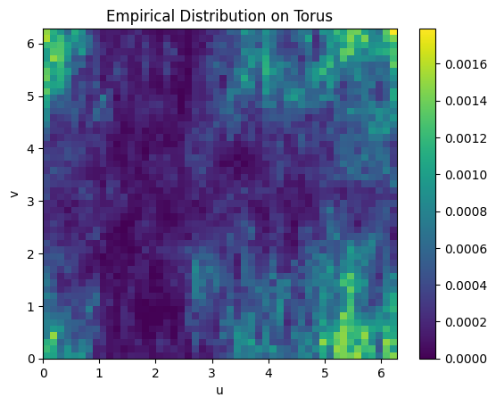

```python
# Compute empirical distribution
# Build 2D histogram of sampled (u, v) values
histogram, u_edges, v_edges = np.histogram2d(u_values, v_values, bins=50, range=[[0, 2*np.pi], [0, 2*np.pi]])

# Normalize to get empirical probability distribution
empirical_density = histogram / np.sum(histogram)

# Plot histogram
plt.imshow(empirical_density.T, origin="lower", extent=[0, 2*np.pi, 0, 2*np.pi], aspect="auto")
plt.xlabel("u")
plt.ylabel("v")
plt.title("Empirical Distribution on Torus")
plt.colorbar()
plt.show()
```

We can now compare the heatmap above to the theoretical probability distribution.

First, the histogram bin centers (for $u$ and $v$ separately) are calculated to create a meshgrid. This is done by adding the leftmost bin with the rightmost bin and dividing the sum by two.

Then, the theoretical density is calculated using the formula, which is expressed as

$$ p(u,v)=\frac{R+r\cos(v)}{4\pi^2R} $$

where $R$ is the major radius and $V$ is the poloidal angle (angle around tube of torus).

Each density is normalized to ensure they have the same scaled. Finally, both the empirical and theoretical densities are plotted on the heatmap.

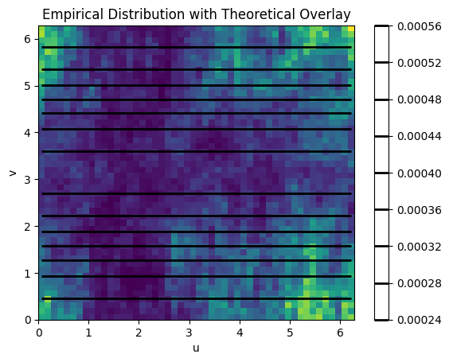

```python
# Overlay theoretical p(u, v)
def compute_densities(empirical_density, u_edges, v_edges):
    # Build theoretical grid
    u_centers = (u_edges[:-1] + u_edges[1:]) / 2
    v_centers = (v_edges[:-1] + v_edges[1:]) / 2
    U, V = np.meshgrid(u_centers, v_centers)

    # Compute theoretical density using formula
    theoretical_density = (R + r*np.cos(V)) / (4 * np.pi**2 * R)

    # Normalize densities
    empirical_density = empirical_density / np.sum(empirical_density)
    theoretical_density = theoretical_density / np.sum(theoretical_density)

    return empirical_density, theoretical_density, U, V

empirical_density, theoretical_density, U, V = compute_densities(empirical_density, u_edges, v_edges)

# Plot
plt.imshow(empirical_density.T, origin="lower", extent=[0, 2*np.pi, 0, 2*np.pi], aspect="auto")
plt.contour(U, V, theoretical_density, colors="black", linewidths=2)
plt.xlabel("u")
plt.ylabel("v")
plt.title("Empirical Distribution with Theoretical Overlay")
plt.colorbar()
plt.show()
```

Kullback-Leibler (KL) divergence is used to measure how close the empirical probability distribution is to the theoretical probability distribution. The formula to determine this value is

$$ D_{\mathrm{KL}}(P \,\|\, Q) = \sum_{i,j} P_{ij} \log\!\left( \frac{P_{ij}}{Q_{ij}} \right) $$

where $P$ is the empirical density, $Q$ is the theoretical density, and $ij$ represents the $ij$th bin of the distribution. Since $log(0)$ is undefined, we only use empirical densities that are greater than 0.

If the KL divergence is exactly zero, the two probability distributions are identical in shape, orientation, and concentration at every coordinate.

```python
# Compute KL divergence vs time
# Skip zero values (since log(0) is undefined)
used = empirical_density > 0

# Compute using formula
KL = np.sum(empirical_density[used] * np.log(empirical_density[used] / theoretical_density[used]))
print(KL)
```

```
0.24456537360499744
```

The KL divergence varies depending on how long the simulation is run for (how many time steps are taken). An array of possible $T$ values is initialized and the empirical and theoretical densities are computed. For each $T$ value, the empirical distribution is built, normalized, and the KL divergence value is computed. Then, these are plotted.

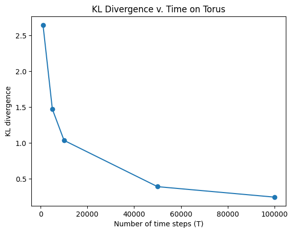

```python
# Plot KL divergence vs time
T_values = [1000, 5000, 10000, 50000, 100000]
empirical_density, theoretical_density, U, V = compute_densities(empirical_density, u_edges, v_edges)
KL_values = []
times = []
for T_i in T_values:
    # Build empirical distribution
    hist, _, _ = np.histogram2d(
        u_values[:T_i],
        v_values[:T_i],
        bins=50,
        range=[[0, 2*np.pi], [0, 2*np.pi]]
    )
    # Normalize empirical density
    P = hist / np.sum(hist)
    # Skip zero values (since log(0) is undefined)
    used = P > 0
    KL = np.sum(P[used] * np.log(P[used] / theoretical_density[used]))
    KL_values.append(KL)
    times.append(T_i)

# Plot
plt.plot(times, KL_values, marker='o')
plt.xlabel("Number of time steps (T)")
plt.ylabel("KL divergence")
plt.title("KL Divergence v. Time on Torus")
plt.show()
```

As seen in the plot of KL divergence vs. time, as the number of time steps increases, the KL divergence decreases. In other words, as the simulation runs for a longer time period, the empirical probability distribution gets closer to the theoretical probability distribution. This is reasonable because for a longer time period, there are more points in the trajectory and hence a larger sample size. A larger sample size correlates to convergence, as seen in the statistical law called the Law of Large Numbers (LLN).